# Phase_2

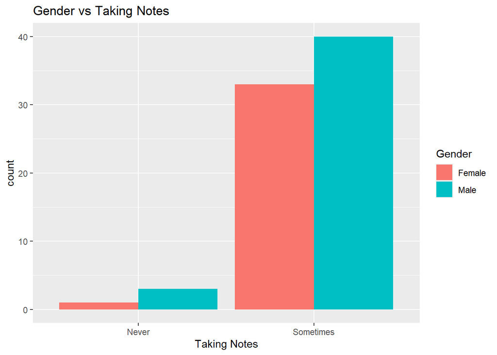

```r
library(ggplot2)
custom_data <- data.frame(
  V1 = Study_Habits$`Taking Notes`,
  V2 = Study_Habits$Gender
)
ggplot(custom_data, aes(x = V1, fill = V2)) +
  geom_bar(position = "dodge") +
  labs(title = "Gender vs Taking Notes ",
       x = "Taking Notes",
       fill = "Gender",
       y = "count")
```

- –Hypothesis testing using chi-squared test–

```r
contingency_table <- table(Study_Habits$`Taking Notes`, Study_Habits$Gender)
chi_squared_result <- chisq.test(contingency_table)
print(chi_squared_result)
```

```
##
##  Pearson's Chi-squared test with Yates' continuity correction
##
## data:  contingency_table
## X-squared = 0.0758, df = 1, p-value = 0.7831
```

- high p-value (greater than 0.05) indicates that the effect of Gender on Taking Notes is not statistically significant. Thus, there’s no evidence that Gender has a meaningful impact on Taking Notes in our dataset
- **#Reviewing Notes vs Gender**
- –Visualization–

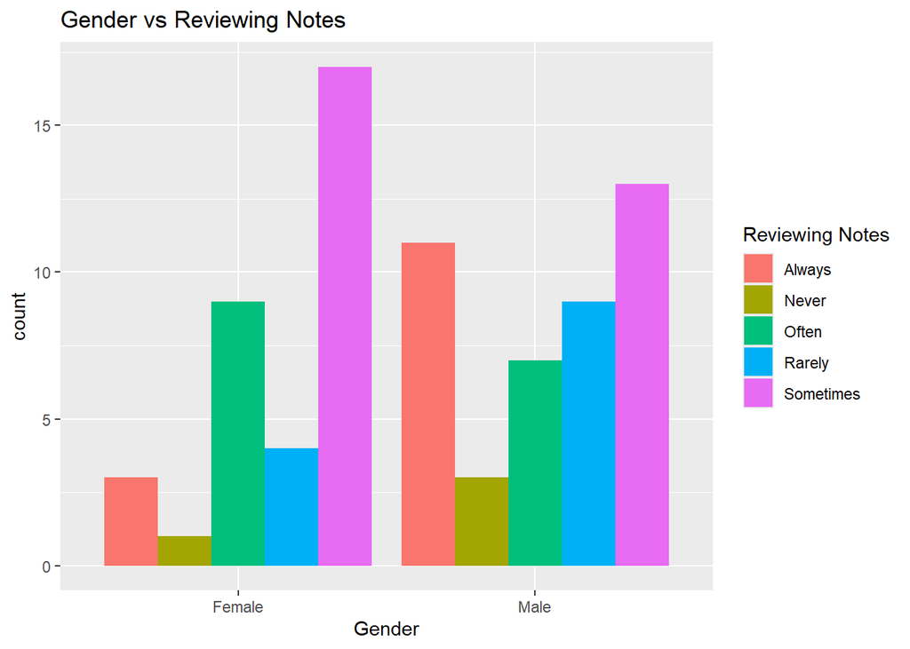

```r
library(ggplot2)
custom_data <- data.frame(
  V1 = Study_Habits$`Reviewing Notes`,
  V2 = Study_Habits$Gender
)
ggplot(custom_data, aes(x = V2, fill = V1)) +
  geom_bar(position = "dodge") +
  labs(title = "Gender vs Reviewing Notes ",
       fill = "Reviewing Notes",
       x = "Gender",
       y = "count")
```

- –Hypothesis testing using chi-squared test–

```r
contingency_table <- table(Study_Habits$`Reviewing Notes`, Study_Habits$Gender)
chi_squared_result <- chisq.test(contingency_table)
print(chi_squared_result)
```

```
##
##  Pearson's Chi-squared test
##
## data:  contingency_table
## X-squared = 7.326, df = 4, p-value = 0.1196
```

- high p-value (greater than 0.05) indicates that the effect of Gender on Reviewing Notes is not statistically significant. Thus, there’s no evidence that Gender has a meaningful impact on Reviewing Notes in our dataset
- **#Organized Material vs Gender**
- –Visualization–

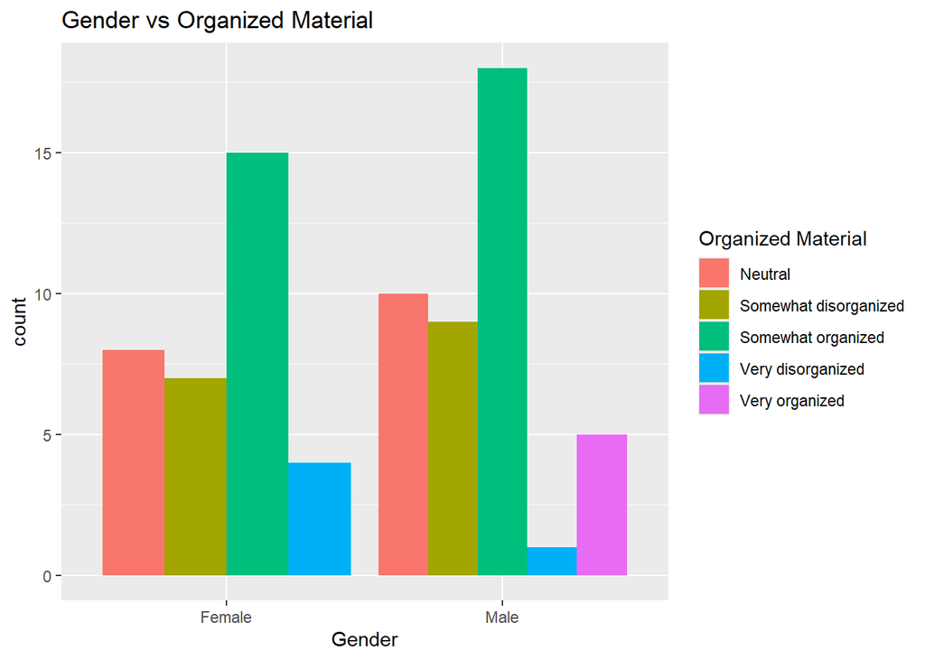

```r
library(ggplot2)
custom_data <- data.frame(
  V1 = Study_Habits$`Organized material`,
  V2 = Study_Habits$Gender
)
ggplot(custom_data, aes(x = V2, fill = V1)) +
  geom_bar(position = "dodge") +
  labs(title = "Gender vs Organized Material ",
       fill = "Organized Material",
       x = "Gender",
       y = "count")
```

- –Hypothesis testing using chi-squared test–

```r
contingency_table <- table(Study_Habits$`Organized material`, Study_Habits$Gender)
chi_squared_result <- chisq.test(contingency_table)
print(chi_squared_result)
```

```
##
##  Pearson's Chi-squared test
##
## data:  contingency_table
## X-squared = 6.5829, df = 4, p-value = 0.1596
```

- high p-value (greater than 0.05) indicates that the effect of Gender on Organized Material is not statistically significant. Thus, there’s no evidence that Gender has a meaningful impact on Organized Material in our dataset
- **#Homework Time vs Gender**
- –Visualization–

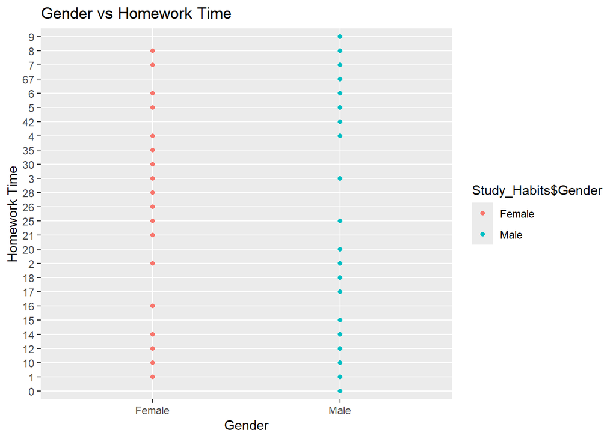

```r
library(ggplot2)
custom_data <- data.frame(
  V1 = Study_Habits$`Homework's time`,
  V2 = Study_Habits$Gender
)
ggplot(custom_data, aes(x = V2, y = V1, color = Study_Habits$Gender)) +
  geom_point() +
  geom_smooth(method = "lm", col = "blue") +
  labs(title = "Gender vs Homework Time ",
       x = "Gender",
       y = "Homework Time")
```

- –Hypothesis testing using chi-squared test–

```r
contingency_table <- table(Study_Habits$`Homework's time`, Study_Habits$Gender)
chi_squared_result <- chisq.test(contingency_table)
print(chi_squared_result)
```

```
##
##  Pearson's Chi-squared test
##
## data:  contingency_table
## X-squared = 23.491, df = 25, p-value = 0.5489
```

- high p-value (greater than 0.05) indicates that the effect of Gender on Homework Time is not statistically significant. Thus, there’s no evidence that Gender has a meaningful impact on Homework Time in our dataset
- **#Planning for study Sessions vs Gender**
- –Visualization–

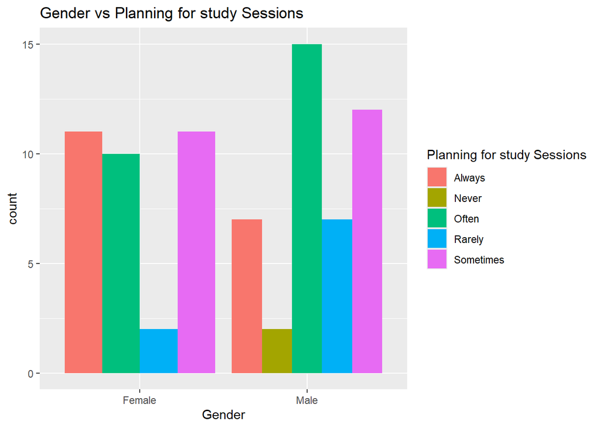

```r
library(ggplot2)
custom_data <- data.frame(
  V1 = Study_Habits$`Planning for study Sessions`,
  V2 = Study_Habits$Gender
)
ggplot(custom_data, aes(x = V2, fill = V1)) +
  geom_bar(position = "dodge") +
  labs(title = "Gender vs Planning for study Sessions ",
       x = "Gender",
       fill = "Planning for study Sessions",
       y = "count")
```

- –Hypothesis testing using chi-squared test–

```r
contingency_table <- table(Study_Habits$`Planning for study Sessions`, Study_Habits$Gender)
chi_squared_result <- chisq.test(contingency_table)
print(chi_squared_result)
```

```
##
##  Pearson's Chi-squared test
##
## data:  contingency_table
## X-squared = 5.7366, df = 4, p-value = 0.2197
```

- high p-value (greater than 0.05) indicates that the effect of Gender on Planning for study Sessions is not statistically significant. Thus, there’s no evidence that Gender has a meaningful impact on Planning for study Sessions in our dataset
- **#Seek academic help vs Gender**
- –Visualization–

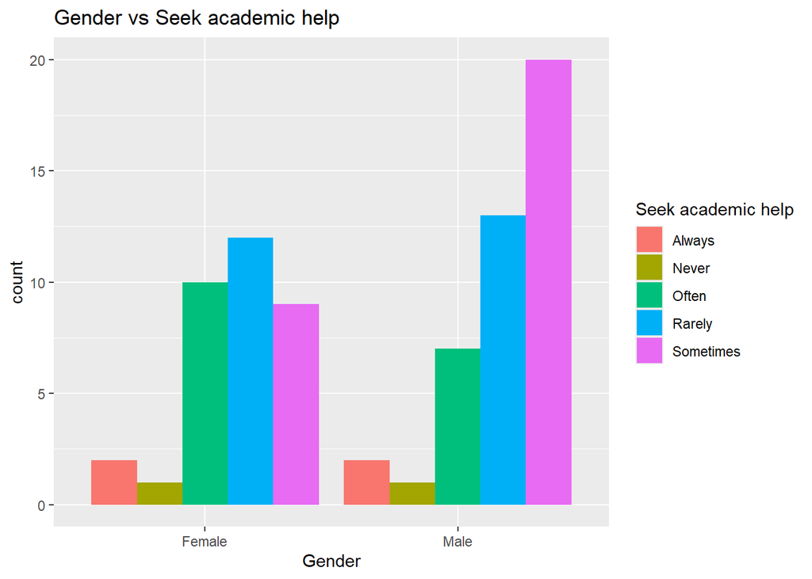

```r
library(ggplot2)
custom_data <- data.frame(
  V1 = Study_Habits$`Seek academic help`,
  V2 = Study_Habits$Gender
)
ggplot(custom_data, aes(x = V2, fill = V1)) +
  geom_bar(position = "dodge") +
  labs(title = "Gender vs Seek academic help ",
       x = "Gender",
       fill = "Seek academic help",
       y = "count")
```

- –Hypothesis testing using chi-squared test–

```r
contingency_table <- table(Study_Habits$`Seek academic help`, Study_Habits$Gender)
chi_squared_result <- chisq.test(contingency_table)
print(chi_squared_result)
```

```
##
##  Pearson's Chi-squared test
##
## data:  contingency_table
## X-squared = 3.741, df = 4, p-value = 0.4422
```

- high p-value (greater than 0.05) indicates that the effect of Gender on Seek academic help is not statistically significant. Thus, there’s no evidence that Gender has a meaningful impact on Seek academic help in our dataset
- **#Confidence in Academic success vs Gender**
- –Visualization–

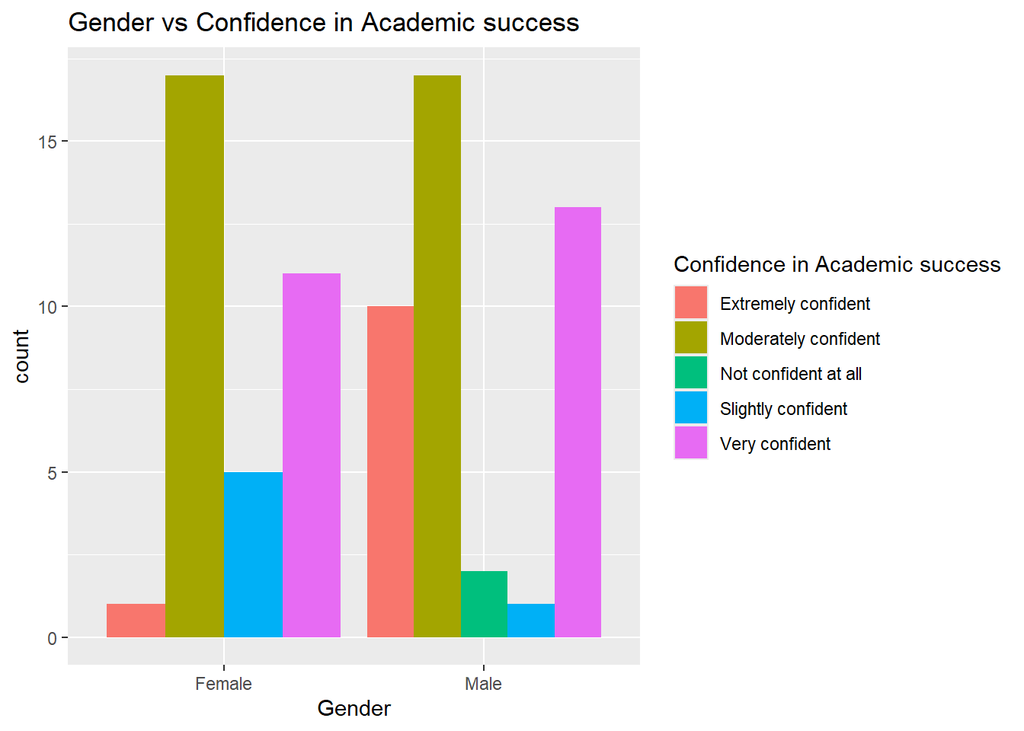

```r
library(ggplot2)
custom_data <- data.frame(
  V1 = Study_Habits$`Confidence in Academic success`,
  V2 = Study_Habits$Gender
)
ggplot(custom_data, aes(x = V2, fill = V1)) +
  geom_bar(position = "dodge") +
  labs(title = "Gender vs Confidence in Academic success ",
       x = "Gender",
       fill = "Confidence in Academic success",
       y = "count")
```

- –Hypothesis testing using chi-squared test–

```r
contingency_table <- table(Study_Habits$`Confidence in Academic success`, Study_Habits$Gender)
chi_squared_result <- chisq.test(contingency_table)
print(chi_squared_result)
```

```
##
##  Pearson's Chi-squared test
##
## data:  contingency_table
## X-squared = 11.299, df = 4, p-value = 0.0234
```

- Appropriate p-value (lower than 0.05) indicates that the effect of Gender on Confidence in Academic success is statistically significant. Thus, there’s enough evidence that Gender has a meaningful impact on Confidence in Academic success in our dataset.
- **#Studying Hours vs Gender**
- –Visualization–

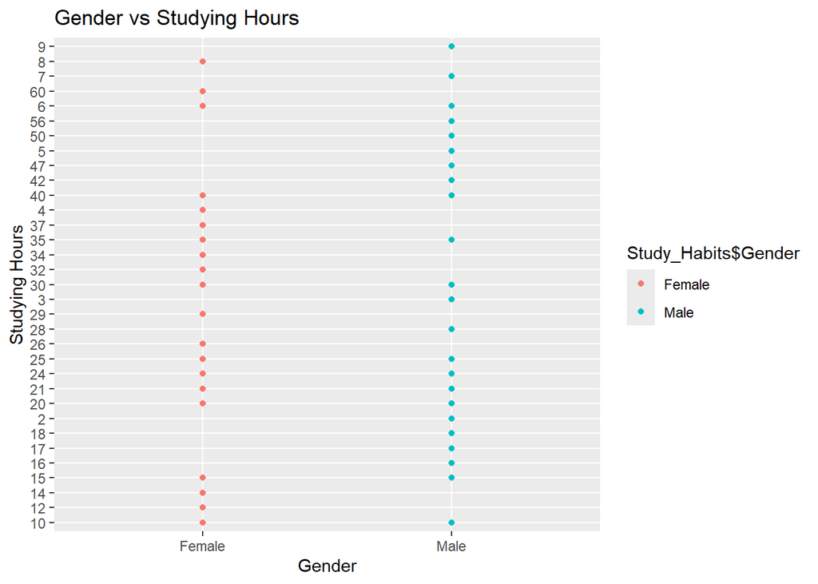

```r
library(ggplot2)
custom_data <- data.frame(
  V1 = Study_Habits$`Studying hours`,
  V2 = Study_Habits$Gender
)
ggplot(custom_data, aes(x = V2, y = V1, color = Study_Habits$Gender)) +
  geom_point() +
  geom_smooth(method = "lm", col = "blue") +
  labs(title = "Gender vs Studying Hours ",
       x = "Gender",
       y = "Studying Hours")
```

- –Hypothesis testing using chi-squared test–

```r
contingency_table <- table(Study_Habits$`Studying hours`, Study_Habits$Gender)
chi_squared_result <- chisq.test(contingency_table)
print(chi_squared_result)
```

```
##
##  Pearson's Chi-squared test
##
## data:  contingency_table
## X-squared = 33.54, df = 32, p-value = 0.3926
```

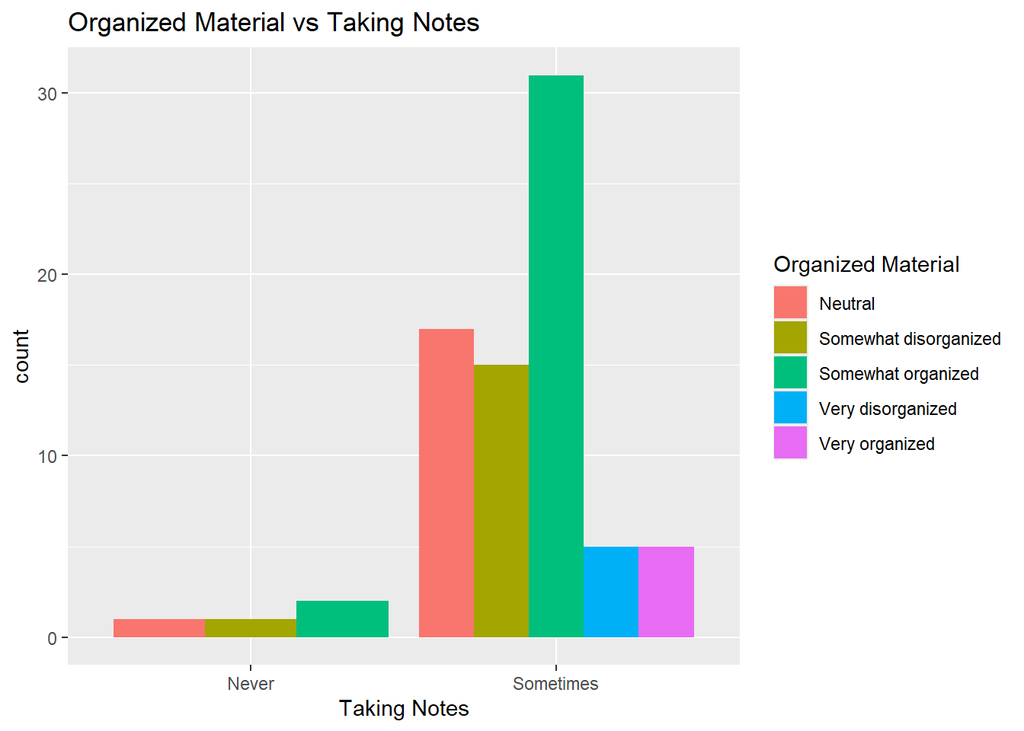

```r
library(ggplot2)
custom_data <- data.frame(
  V1 = Study_Habits$`Taking Notes`,
  V2 = Study_Habits$`Organized material`
)
ggplot(custom_data, aes(x = V1, fill = V2)) +
  geom_bar(position = "dodge") +
  labs(title = "Organized Material vs Taking Notes ",
       x = "Taking Notes",
       fill = "Organized Material",
       y = "count")
```

- –Hypothesis testing using chi-squared test–

```r
contingency_table <- table(Study_Habits$`Taking Notes`, Study_Habits$`Organized material`)
chi_squared_result <- chisq.test(contingency_table)
print(chi_squared_result)
```

```
##
##  Pearson's Chi-squared test
##
## data:  contingency_table
## X-squared = 0.6391, df = 4, p-value = 0.9586
```

- high p-value (greater than 0.05) indicates that the effect of Organized Material on Taking Notes is not statistically significant. Thus, there’s no evidence that Organized Material has a meaningful impact on Taking Notes in our dataset
- **#Taking Notes vs Confidence in Academic success**
- –Visualization–

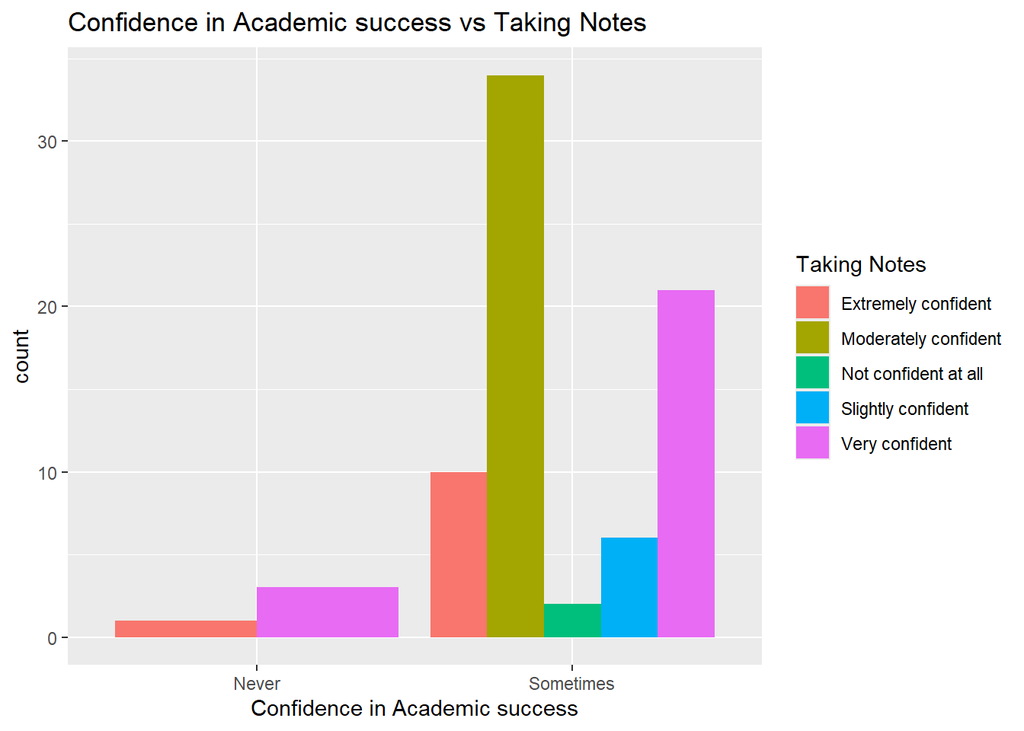

```r
library(ggplot2)
custom_data <- data.frame(
  V1 = Study_Habits$`Confidence in Academic success`,
  V2 = Study_Habits$`Taking Notes`
)
ggplot(custom_data, aes(x = V2, fill = V1)) +
  geom_bar(position = "dodge") +
  labs(title = "Confidence in Academic success vs Taking Notes ",
       fill = "Taking Notes",
       x = "Confidence in Academic success",
       y = "count")
```

- –Hypothesis testing using chi-squared test–

```r
contingency_table <- table(Study_Habits$`Taking Notes`, Study_Habits$`Confidence in Academic success`)
chi_squared_result <- chisq.test(contingency_table)
print(chi_squared_result)
```

```
##
##  Pearson's Chi-squared test
##
## data:  contingency_table
## X-squared = 5.241, df = 4, p-value = 0.2635
```

- high p-value (greater than 0.05) indicates that the effect of Confidence in Academic success on Taking Notes is not statistically significant. Thus, there’s no evidence that Confidence in Academic success has a meaningful impact on Taking Notes in our dataset
- **#Taking Notes vs Studying hours**
- –Visualization–

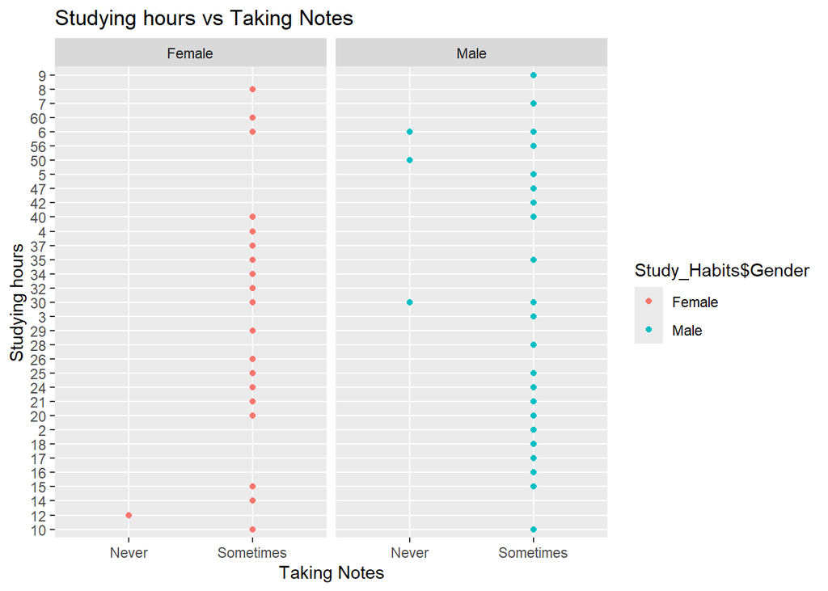

```r
library(ggplot2)
custom_data <- data.frame(
  V1 = Study_Habits$`Taking Notes`,
  V2 = Study_Habits$`Studying hours`
)
ggplot(custom_data, aes(x = V1, y = V2, color = Study_Habits$Gender)) +
  geom_point() +
  geom_smooth(method = "lm", col = "blue") +
  facet_wrap(~ Study_Habits$Gender) +
  labs(title = "Studying hours vs Taking Notes ",
       x = "Taking Notes",
       y = "Studying hours")
```

- –Hypothesis testing using chi-squared test–

```r
contingency_table <- table(Study_Habits$`Taking Notes`, Study_Habits$`Studying hours`)
chi_squared_result <- chisq.test(contingency_table)
print(chi_squared_result)
```

```
##
##  Pearson's Chi-squared test
##
## data:  contingency_table
## X-squared = 41.805, df = 32, p-value = 0.115
```

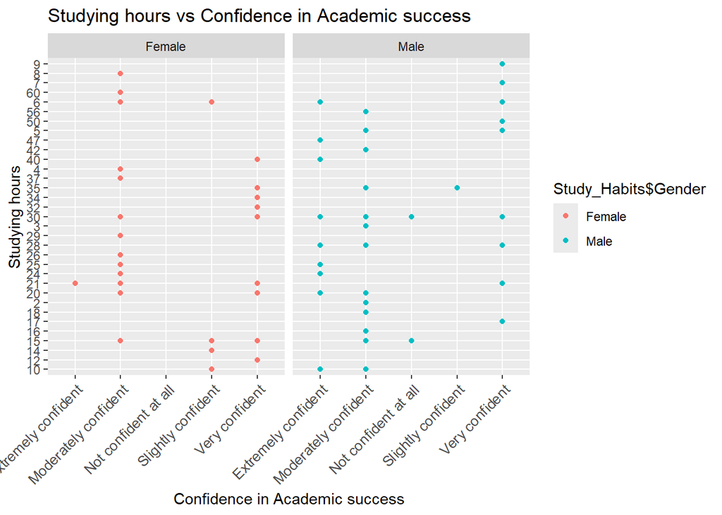

```r
library(ggplot2)
custom_data <- data.frame(
  V1 = Study_Habits$`Confidence in Academic success`,
  V2 = Study_Habits$`Studying hours`
)
ggplot(custom_data, aes(x = V1, y = V2, color = Study_Habits$Gender)) +
  geom_point() +
  geom_smooth(method = "lm", col = "blue") +
  facet_wrap(~ Study_Habits$Gender) +
  labs(title = "Studying hours vs Confidence in Academic success ",
       x = "Confidence in Academic success",
       y = "Studying hours")+
    theme(axis.text.x = element_text(size = 10, angle = 45, hjust = 1))  # Adjust x-axis text properties
```

- –Hypothesis testing using chi-squared test–

```r
contingency_table <- table(Study_Habits$`Confidence in Academic success`, Study_Habits$`Studying hours`)
chi_squared_result <- chisq.test(contingency_table)
print(chi_squared_result)
```

```
##
##  Pearson's Chi-squared test
##
## data:  contingency_table
## X-squared = 95.168, df = 128, p-value = 0.9867
```

- high p-value (greater than 0.05) indicates that the effect of Studying hours on Confidence in Academic success is not statistically significant. Thus, there’s no evidence that Studying hours has a meaningful impact on Confidence in Academic success in our dataset
- **#Confidence in Academic success vs Family Structure**
- –Visualization–

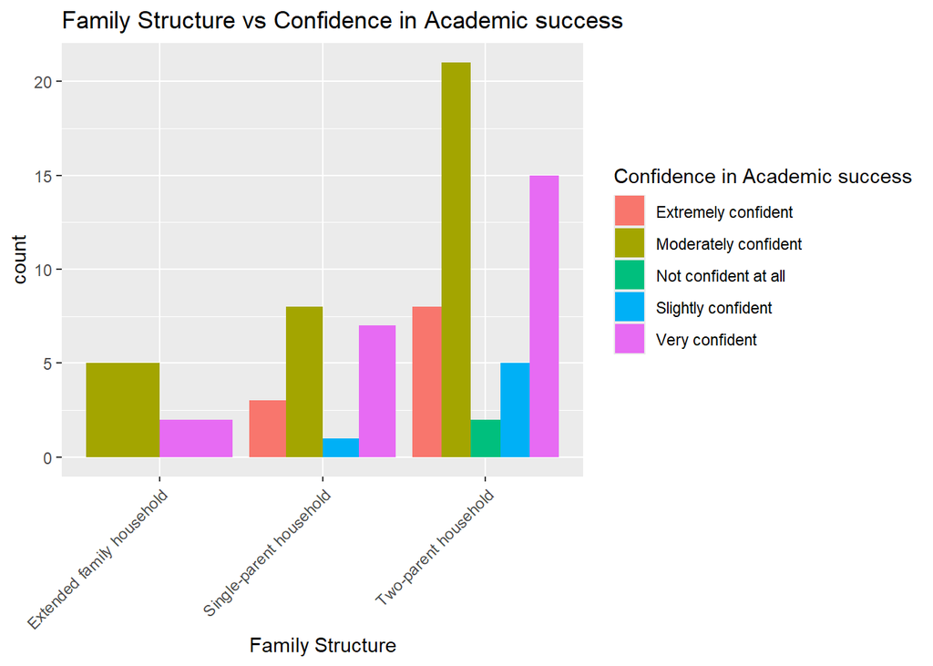

```r
library(ggplot2)
custom_data <- data.frame(
  V1 = Study_Habits$`Confidence in Academic success`,
  V2 = Study_Habits$`Family Structure`
)
ggplot(custom_data, aes(x = V2, fill = V1)) +
  geom_bar(position = "dodge") +
  labs(title = "Family Structure vs Confidence in Academic success ",
       fill = "Confidence in Academic success",
       x = "Family Structure",
       y = "count")+
    theme(axis.text.x = element_text(angle = 45, hjust = 1))
```

- –Hypothesis testing using chi-squared test–

```r
contingency_table <- table(Study_Habits$`Confidence in Academic success`, Study_Habits$`Family Structure`)
chi_squared_result <- chisq.test(contingency_table)
print(chi_squared_result)
```

```
##
##  Pearson's Chi-squared test
##
## data:  contingency_table
## X-squared = 4.6476, df = 8, p-value = 0.7945
```

- high p-value (greater than 0.05) indicates that the effect of Family Structure on Confidence in Academic success is not statistically significant. Thus, there’s no evidence that Family Structure has a meaningful impact on Confidence in Academic success in our dataset
- **#Reviewing Notes vs Exam Preparation**
- –Visualization–

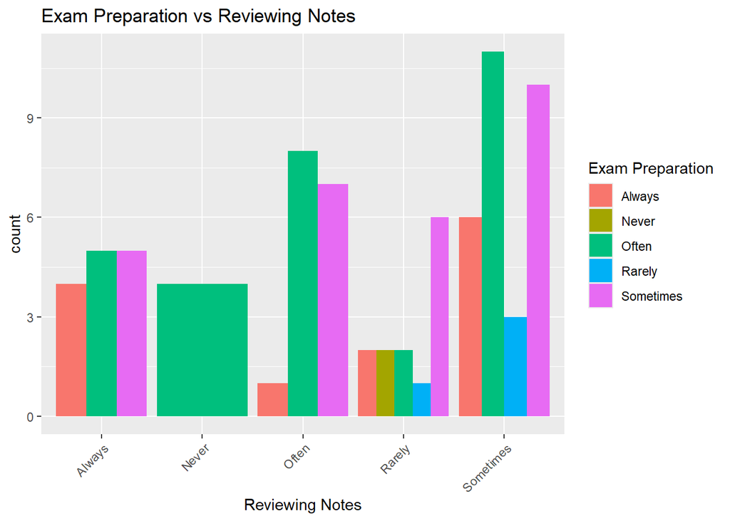

```r
library(ggplot2)
custom_data <- data.frame(
  V1 = Study_Habits$`Reviewing Notes`,
  V2 = Study_Habits$`Exam Preparation`
)
ggplot(custom_data, aes(x = V1, fill = V2)) +
  geom_bar(position = "dodge") +
  labs(title = "Exam Preparation vs Reviewing Notes ",
       x = "Reviewing Notes",
       fill = "Exam Preparation",
       y = "count")+
    theme(axis.text.x = element_text(angle = 45, hjust = 1))
```

- –Hypothesis testing using chi-squared test–

```r
contingency_table <- table(Study_Habits$`Reviewing Notes`, Study_Habits$`Exam Preparation`)
chi_squared_result <- chisq.test(contingency_table)
print(chi_squared_result)
```

```
##
##  Pearson's Chi-squared test
##
## data:  contingency_table
## X-squared = 24.545, df = 16, p-value = 0.07826
```

- high p-value (greater than 0.05) indicates that the effect of Reviewing Notes on Exam Preparation is not statistically significant. Thus, there’s no evidence that Reviewing Notes has a meaningful impact on Exam Preparation in our dataset
- **#Father Education vs Mother Education**
- –Visualization–

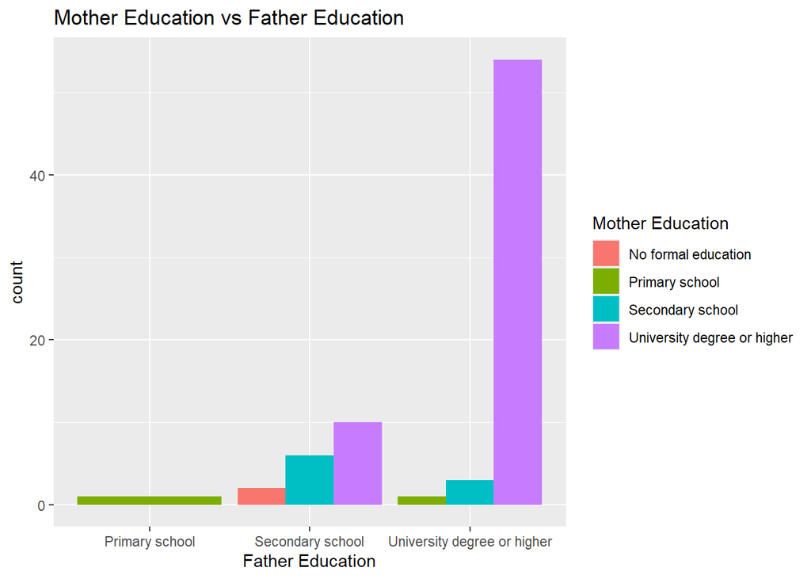

```r
library(ggplot2)
custom_data <- data.frame(
  V1 = Study_Habits$`Parents Education Level`,
  V2 = Study_Habits$`Parents Education Level2`
)
ggplot(custom_data, aes(x = V1, fill = V2)) +
  geom_bar(position = "dodge") +
  labs(title = "Mother Education vs Father Education ",
       x = "Father Education",
       fill = "Mother Education",
       y = "count")
```

- –Hypothesis testing using chi-squared test–

```r
contingency_table <- table(Study_Habits$`Parents Education Level`, Study_Habits$`Parents Education Level2`)
chi_squared_result <- chisq.test(contingency_table)
print(chi_squared_result)
```

```
##
##  Pearson's Chi-squared test
##
## data:  contingency_table
## X-squared = 56.33, df = 6, p-value = 2.496e-10
```

- Appropriate p-value (lower than 0.05) indicates that the effect of Father Education level on Mother Education Level is statistically significant. Thus, there’s enough evidence that Father Education level has a meaningful impact on Mother Education Level in our dataset.
- **#Family Structure vs Lifestyle Factors**
- –Visualization–

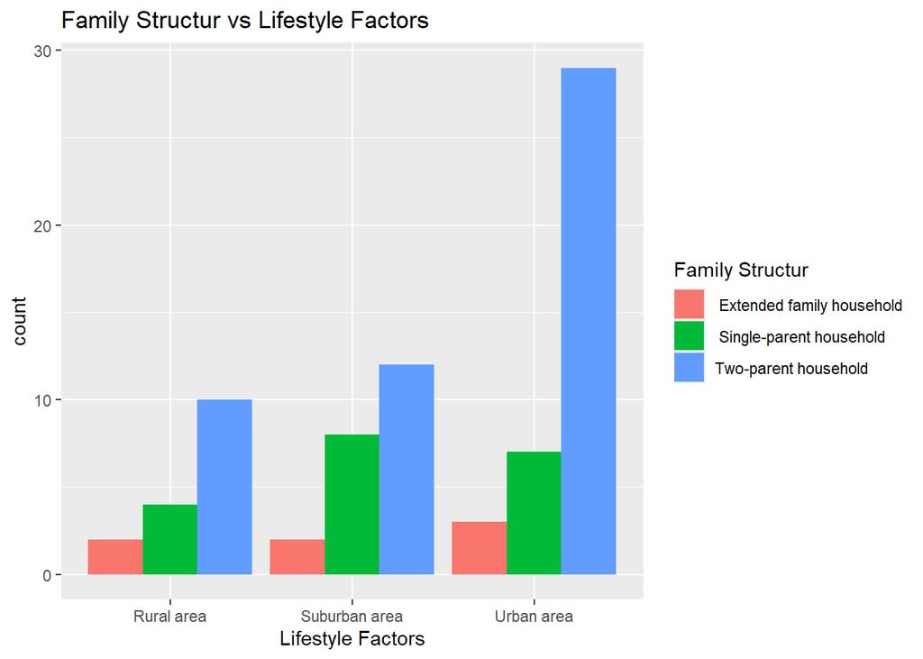

```r
library(ggplot2)
custom_data <- data.frame(
  V1 = Study_Habits$`  Lifestyle Factors (Urban vs. Rural Living)`,
  V2 = Study_Habits$`Family Structure`
)
ggplot(custom_data, aes(x = V1, fill = V2)) +
  geom_bar(position = "dodge") +
  labs(title = "Family Structur vs Lifestyle Factors ",
       x = "Lifestyle Factors",
       fill = "Family Structur",
       y = "count")
```

- –Hypothesis testing using chi-squared test–

```r
contingency_table <- table(Study_Habits$`Family Structure`, Study_Habits$`  Lifestyle Factors (Urban vs. Rural Living)`)
chi_squared_result <- chisq.test(contingency_table)
print(chi_squared_result)
```

```
##
##  Pearson's Chi-squared test
##
## data:  contingency_table
## X-squared = 3.0985, df = 4, p-value = 0.5415
```

- high p-value (greater than 0.05) indicates that the effect of Family Structure on Lifestyle Factors is not statistically significant. Thus, there’s no evidence that Family Structure has a meaningful impact on Lifestyle Factors in our dataset
- **#Digital Access vs Lifestyle Factors**
- –Visualization–

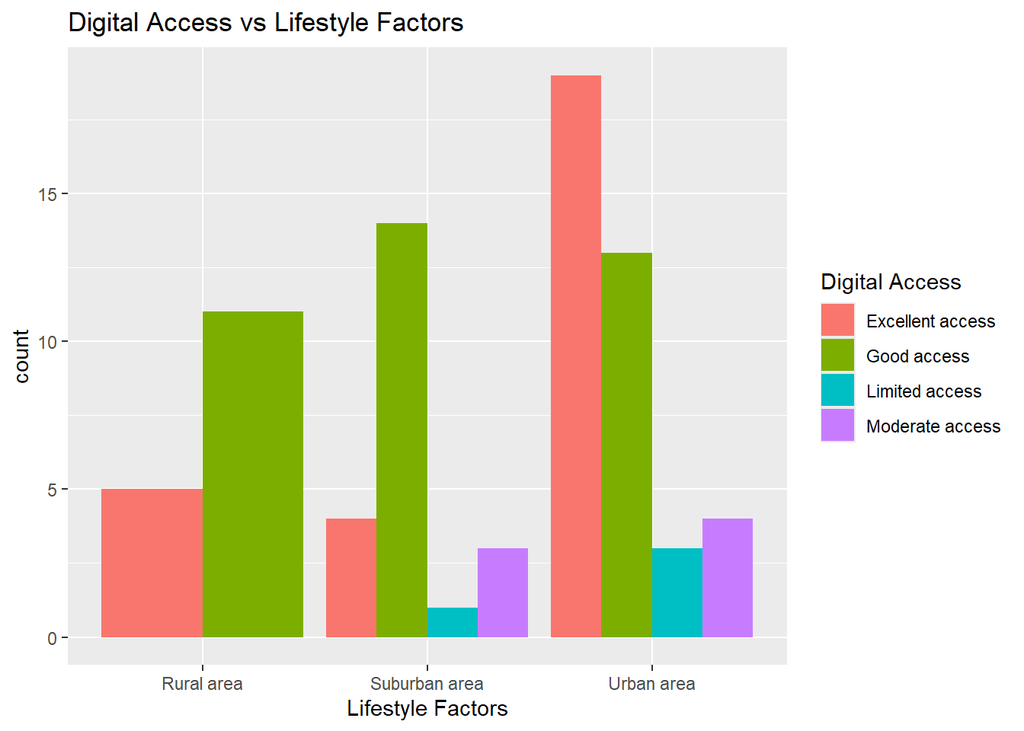

```r
library(ggplot2)
custom_data <- data.frame(
  V1 = Study_Habits$`  Lifestyle Factors (Urban vs. Rural Living)`,
  V2 = Study_Habits$`Digital Access`
)
ggplot(custom_data, aes(x = V1, fill = V2)) +
  geom_bar(position = "dodge") +
  labs(title = "Digital Access vs Lifestyle Factors ",
       x = "Lifestyle Factors",
       fill = "Digital Access",
       y = "count")
```

- –Hypothesis testing using chi-squared test–

```r
contingency_table <- table(Study_Habits$`  Lifestyle Factors (Urban vs. Rural Living)`, Study_Habits$`Digital Access`)
chi_squared_result <- chisq.test(contingency_table)
print(chi_squared_result)
```

```
##
##  Pearson's Chi-squared test
##
## data:  contingency_table
## X-squared = 11.239, df = 6, p-value = 0.08125
```

- high p-value (greater than 0.05) indicates that the effect of Lifestyle Factors on Digital Access is not statistically significant. Thus, there’s no evidence that Lifestyle Factors has a meaningful impact on Digital Access in our dataset
- **#Digital Access vs Study Environment**
- –Visualization–

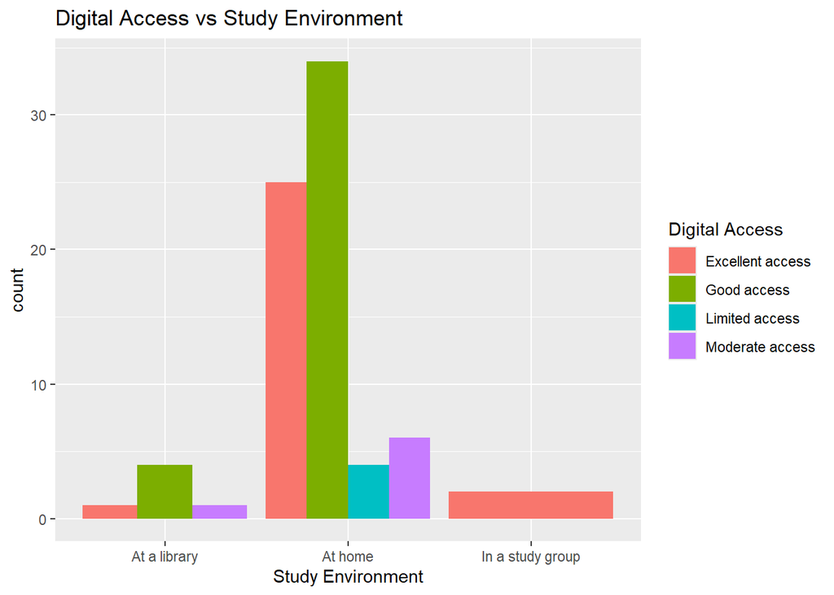

```r
library(ggplot2)
custom_data <- data.frame(
  V1 = Study_Habits$`Study Environment`,
  V2 = Study_Habits$`Digital Access`
)
ggplot(custom_data, aes(x = V1, fill = V2)) +
  geom_bar(position = "dodge") +
  labs(title = "Digital Access vs Study Environment ",
       x = "Study Environment",
       fill = "Digital Access",
       y = "count")
```

- –Hypothesis testing using chi-squared test–

```r
contingency_table <- table(Study_Habits$`Study Environment`, Study_Habits$`Digital Access`)
chi_squared_result <- chisq.test(contingency_table)
print(chi_squared_result)
```

```
##
##  Pearson's Chi-squared test
##
## data:  contingency_table
## X-squared = 5.2556, df = 6, p-value = 0.5115
```

- high p-value (greater than 0.05) indicates that the effect of Digital Access on Study Environment is not statistically significant. Thus, there’s no evidence that Digital Access has a meaningful impact on Study Environment in our dataset
- **#Life Style vs Study Environment**
- –Visualization–

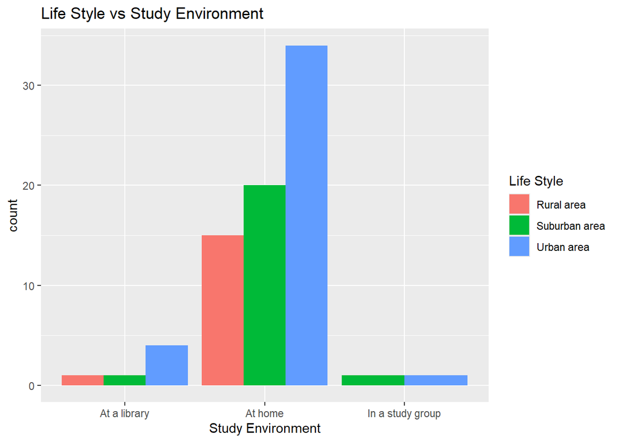

```r
library(ggplot2)
custom_data <- data.frame(
  V1 = Study_Habits$`Study Environment`,
  V2 = Study_Habits$`  Lifestyle Factors (Urban vs. Rural Living)`
)
ggplot(custom_data, aes(x = V1, fill = V2)) +
  geom_bar(position = "dodge") +
  labs(title = "Life Style vs Study Environment ",
       x = "Study Environment",
       fill = "Life Style",
       y = "count")
```

- –Hypothesis testing using chi-squared test–

```r
contingency_table <- table(Study_Habits$`Study Environment`, Study_Habits$`  Lifestyle Factors (Urban vs. Rural Living)`)
chi_squared_result <- chisq.test(contingency_table)
print(chi_squared_result)
```

```
##
##  Pearson's Chi-squared test
##
## data:  contingency_table
## X-squared = 1.448, df = 4, p-value = 0.8358
```

- high p-value (greater than 0.05) indicates that the effect of Life Style on Study Environment is not statistically significant. Thus, there’s no evidence that Life Style has a meaningful impact on Study Environment in our dataset
- **#Family Structure vs Study Environment**
- –Visualization–

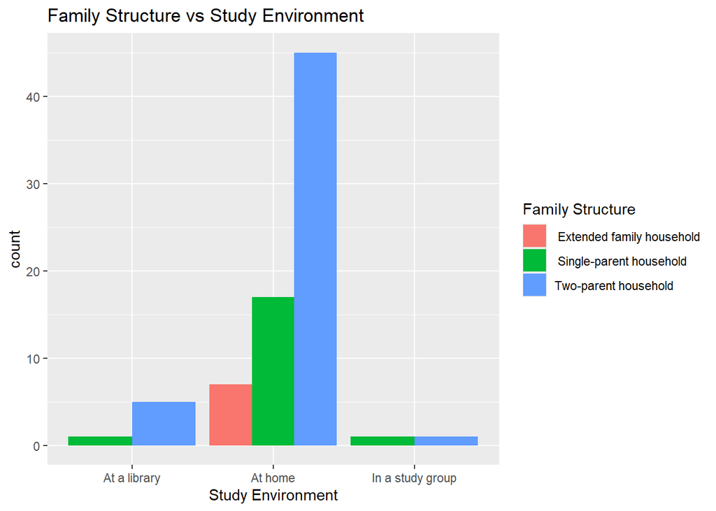

```r
library(ggplot2)
custom_data <- data.frame(
  V1 = Study_Habits$`Study Environment`,
  V2 = Study_Habits$`Family Structure`
)
ggplot(custom_data, aes(x = V1, fill = V2)) +
  geom_bar(position = "dodge") +
  labs(title = "Family Structure vs Study Environment ",
       x = "Study Environment",
       fill = "Family Structure",
       y = "count")
```

- –Hypothesis testing using chi-squared test–

```r
contingency_table <- table(Study_Habits$`Study Environment`, Study_Habits$`Family Structure`)
chi_squared_result <- chisq.test(contingency_table)
print(chi_squared_result)
```

```
##
##  Pearson's Chi-squared test
##
## data:  contingency_table
## X-squared = 1.8426, df = 4, p-value = 0.7647
```

- high p-value (greater than 0.05) indicates that the effect of Family Structure on Study Environment is not statistically significant. Thus, there’s no evidence that Family Structure has a meaningful impact on Study Environment in our dataset

# Interpretation of the correlated variables

### 1. GPA vs Reviewing Notes

- The regression analysis revealed that reviewing notes is a significant predictor of GPA.
- These findings suggest that the habit of reviewing notes, especially regularly, has a statistically significant but varying impact on academic performance.

### 2. Homework’s Time vs Studying Methods

- The chi-squared test indicates a significant association between the time spent on homework and preferred studying methods ($X^2 = 146.48, df = 100, p = 0.0017$).
- This suggests that students’ studying methods strongly correlate with how much time they dedicate to homework, implying that tailored guidance on study strategies could optimize time management.

### 3. Confidence in Academic Success vs Gender

- The chi-squared test showed a significant association between gender and confidence levels in academic success ($X^2 = 11.299, df = 4, p = 0.0234$).
- This finding highlights potential gender disparities in self-assessment of academic abilities, warranting initiatives to boost confidence among underrepresented groups.

### 4. Father’s Education vs Mother’s Education

- A highly significant relationship was found between fathers’ and mothers’ education levels ($X^2 = 56.33, df = 6, p < 0.001$).
- This indicates that parental educational attainment is interrelated, reflecting socio-economic patterns that may influence students’ educational experiences.

# Further analysis for GPA vs Reviewing Notes

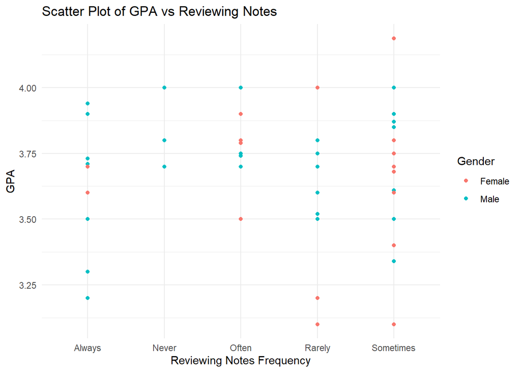

```r
library(ggplot2)
custom_data <- data.frame(
  Review = Study_Habits$`Reviewing Notes`,
  GPA = GPA
)
ggplot(custom_data, aes(x = Review, y = GPA, color = Study_Habits$Gender)) +
  geom_point() +
  geom_smooth(method = "lm", se = FALSE, color = "blue") +
  labs(title = "Scatter Plot of GPA vs Reviewing Notes",
       x = "Reviewing Notes Frequency",
       y = "GPA",
       color = "Gender") +
  theme_minimal()
```

```r
model <- lm(GPA ~ Review, data = custom_data)
coefficients <- coef(model)
equation <- paste0("GPA = ", round(coefficients[1], 3), " + ",
                   round(coefficients[2], 3), "*Review_Level")
equation
```

```
## [1] "GPA = 3.606 + 0.269*Review_Level"
```

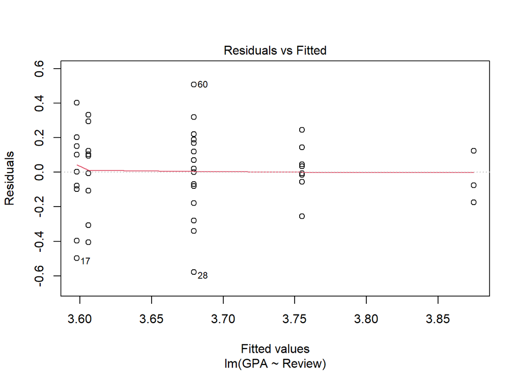

```r
plot(model, which = 1)
```

- The spread of residuals appears relatively constant across the fitted values, indicating that there is no obvious pattern in the residuals. This suggests that the assumption of constant variance (homoscedasticity) holds. - The red horizontal line at zero indicates that the average residual is close to zero, which suggests that the model is fitting the data well. - Normal Q-Q plot

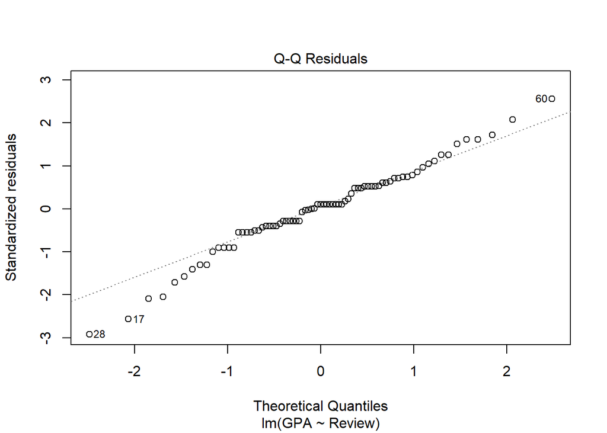

```r
plot(model, which = 2)
```

- The points approximately follow the reference line, indicating that the residuals are normally distributed, which aligns with the assumptions of the linear regression model. - The summary statistics show that the model explains about 12.19% of the variance in GPA, with a residual standard error of 0.2018. The p-value for the regression model is 0.04994, which is less than 0.05, suggesting that the relationship between GPA and reviewing notes frequency is statistically significant. - Summary statistics:

```r
summary(model)
```

```
##
## Call:
## lm(formula = GPA ~ Review, data = custom_data)
##
## Residuals:
##      Min       1Q   Median       3Q      Max
## -0.57960 -0.09769  0.02040  0.12040  0.50840
##
## Coefficients:
##                  Estimate Std. Error t value Pr(>|t|)
## (Intercept)      3.605714   0.053932  66.857   <2e-16 ***
## ReviewNever      0.269286   0.114407   2.354   0.0213 *
## ReviewOften      0.149286   0.073849   2.021   0.0469 *
## ReviewRarely    -0.008022   0.077724  -0.103   0.9181
## ReviewSometimes  0.073886   0.065315   1.131   0.2617
## ---
## Signif. codes:  0 '***' 0.001 '**' 0.01 '*' 0.05 '.' 0.1 ' ' 1
##
## Residual standard error: 0.2018 on 72 degrees of freedom
## Multiple R-squared:  0.1219, Adjusted R-squared:  0.07316
## F-statistic:   2.5 on 4 and 72 DF,  p-value: 0.04994
```

- R-squared and Adjusted R-squared:

```r
r_squared <- summary(model)$r.squared
adjusted_r_squared <- summary(model)$adj.r.squared
c(r_squared, adjusted_r_squared)
```

```
## [1] 0.12193976 0.07315863
```

```r
aggregate(GPA ~ Review, data = custom_data, FUN = mean)
```

```
##      Review      GPA
## 1    Always 3.605714
## 2     Never 3.875000
## 3     Often 3.755000
## 4    Rarely 3.597692
## 5 Sometimes 3.679600
```

```r
anova(model)
```

```
## Analysis of Variance Table
##
## Response: GPA
##           Df  Sum Sq  Mean Sq F value  Pr(>F)
## Review     4 0.40717 0.101792  2.4997 0.04994 *
## Residuals 72 2.93193 0.040721
## ---
## Signif. codes:  0 '***' 0.001 '**' 0.01 '*' 0.05 '.' 0.1 ' ' 1
```

- The ANOVA results indicate that there is a significant difference in GPA across the different review groups, with an F-value of 2.4997 and a p-value of 0.04994. Since the p-value is less than 0.05, we reject the null hypothesis, suggesting that at least one group mean is significantly different from others.
- Effect Size: Calculate eta squared to quantify effect size

```r
model <- lm(GPA ~ Review, data = custom_data)
library(lsr)
eta_squared <- etaSquared(model)
eta_squared
```

```
##           eta.sq eta.sq.part
## Review 0.1219398   0.1219398
```

- Eta squared of 0.1219398 quantifies the proportion of variance in GPA that is explained by review frequency. This indicates a small to moderate effect size. It suggests that review frequency accounts for a noticeable but not large part of the variation in GPA.

# Summary of the further analysis

# References:

- Walck-Shannon, E. M., Rowell, S. F., & Frey, R. F. (2021). To What Extent Do Study Habits Relate to Performance?. CBE life sciences education, 20(1), ar6. https://doi.org/10.1187/cbe.20-05-0091